# 修bug之前，先让AI出两道题｜上下文的纪律 · 第 4 篇

「上下文的纪律」系列 · 第 4 篇

先分析问题再动手修改，bug修复失败案例中至少22.4%可以挽回

▍AI改bug，过程往往很流畅，但成功率不稳定

编码智能体修改bug的失败里，有一种常见的失败情景：对问题的分析写得头头是道，改动本身也不报错，一跑回归测试，发现问题仍然存在。这类失败和模型的推理能力关系不大，主要原因是没能找到与问题对应的上下文信息：跨模块依赖、接口的隐式契约、数据流的来龙去脉。这些知识隐藏在代码里，并不直接在issue描述里体现。AI往往只在发生issue的模块寻找原因，因此跨模块问题的修复成功率会很低。（可以参考上一篇论文荐读中，关于AI自行查找代码仓库上下文信息的研究。）

有经验的工程师面对bug时，首先会梳理整体的处理逻辑：这个组件正常情况下怎么工作？这个接口对调用方有什么约定？相关代码在哪个模块？对整个逻辑过程和依赖关系有了全面理解以后，再决定改哪里。上海交通大学团队今年发表的这篇论文，把“先问后修”做成了自动流程，并且通过实验对这套工作流程的价值做了量化评估。

本期论文

Know Before Fix: QA-Driven Repository Knowledge Acquisition for Software Issue Resolution  
修bug之前先弄懂：问答驱动的仓库知识获取  
Haotian Lin et al.（上海交通大学、匹兹堡大学、广东以色列理工学院），2026-07（arXiv:2607.11111）

简要结论：动手修复之前，先让智能体把issue拆成几个具体问题、逐题探索作答，再把问答注入修复流程——SWE-bench Verified上Pass@1提升3.8–4.4个百分点。实验显示使用这一方法，原先直接把Issue扔给AI修复失败的案例中有22.4%可以被挽回。

名词速查

▸ pre-repair（修复前探索）：在生成补丁之前先在仓库里收集信息的一类方法，常见做法是给出可疑文件位置或结构摘要。

▸ SWE-bench Verified：从真实GitHub issue构建的修复任务基准的精校子集，总共500个实例，用开发者编写的测试判定补丁是否真正解决问题。

▸ Pass@1：单次尝试生成补丁并通过测试的比例。

▸ Oracle实验：把现实中拿不到的信息（标准答案补丁、标准文件集）交给实验流程，用来测一个方法的价值上限。

▸ Mini-SWE-Agent：一个最小化的shell交互式修复智能体，在论文中用作对照的基础底座。

## 一、一类常见的修复失败：缺在仓库知识，不在推理能力

论文的动机建立在一组实证观察上：多项研究把“仓库知识不足”列为修复智能体失败的主要原因之一，表现形态包括关键词式的浅层定位、跨模块追踪断链、违反隐式接口约定、不了解外部协议的行为。这些失败有一个共同点：推理过程本身没有问题，错在缺少解决问题所需的必要信息。

为了验证“补全知识就能做对”，论文先做了一个Oracle实验。让基础修复智能体（Mini-SWE-Agent配DeepSeek-V3.2）先跑一遍SWE-bench Lite，得到116个失败实例；然后构造一对Oracle问答——出题者根据标准答案补丁，提出一个最关键的问题。作答者只能读标准答案涉及的文件，据此给出回答。把这一问一答注入原流程重跑：116个失败里有26个可以正确修复，恢复率22.4%。

这个“恢复率”的含义是：实验设定为一次只问一个问题、作答只允许读标准文件——所以22.4%是这一流程方法提升bug修复能力的下界而不是上限。它可以证明：对相当一部分失败案例，失败的原因是对代码仓库的上下文知识理解不足。

"…they first ask diagnostic questions about the code, such as how a component behaves, what contracts an API enforces, or where relevant modules reside, building the necessary understanding before committing to any repair strategy."  
── 中译：他们先就代码提出诊断性问题——某个组件如何运作、某个接口强制什么约定、相关模块位于何处。在确定修复策略之前，先建立必要的理解。（原论文§II，描述有经验的工程师）

## 二、ACQUIRE的两阶段设计：先出题作答，再着手修复

Oracle实验中所使用的标准答案补丁在现实中无法在修复完成前就得到。ACQUIRE做的事是把这套流程自动化。整体分两段：第一段获取知识，一个出题者提出N个问题，N个作答者并行探索仓库、给出带证据的回答。第二段修复，修复者带着这组问答进行实际的代码修复工作。

出题环节的关键设计是四类问题模板。五名研究生分析了116个Oracle问题，归纳出四类反复出现的知识维度，作为出题者的结构化模板：

| 类别 | 问什么 | 示例 | 占Oracle问题比例 |
| --- | --- | --- | --- |
| 机制与行为 | 逻辑流、状态管理、数据处理如何运作 | 认证系统如何校验用户凭据？ | 70.7% |
| 设计与用法 | API定义、类层级、错误规约、设计惯例 | 数据库连接类的接口契约是什么？ | 18.1% |
| 定位与结构 | 代码布局、模块组织、依赖关系 | 登录功能实现在哪里？ | 7.8% |
| 生态与标准 | 外部库行为、协议约束、语言语义 | HTTP/1.1对分块传输编码有什么要求？ | 3.4% |

表 1｜四类问题模板（原论文§III-B1，作者整理）。模板是参考引导，出题者按实际问题自由选择，并不限定每个类别的实际比例

作答者与修复智能体共用同一套shell环境，但运行在只读模式，有三条规约：1. 答案必须引用具体的文件路径、函数名或代码行为；2. 证据够了就提交；3. 找不到证据就明确说存在缺口，不得编造。N个作答实例彼此隔离、并行执行，互相看不到对方的探索轨迹。这样既防止交叉污染，也能减少总体耗时。

修复阶段，N组问答序列化成一个文本块，一次性注入修复者的上下文，放在修复指令之前。论文解释了不用“边修边动态注入”的理由：保持两阶段的模块化，并保证修复者的第一步决策就有完整知识可用。

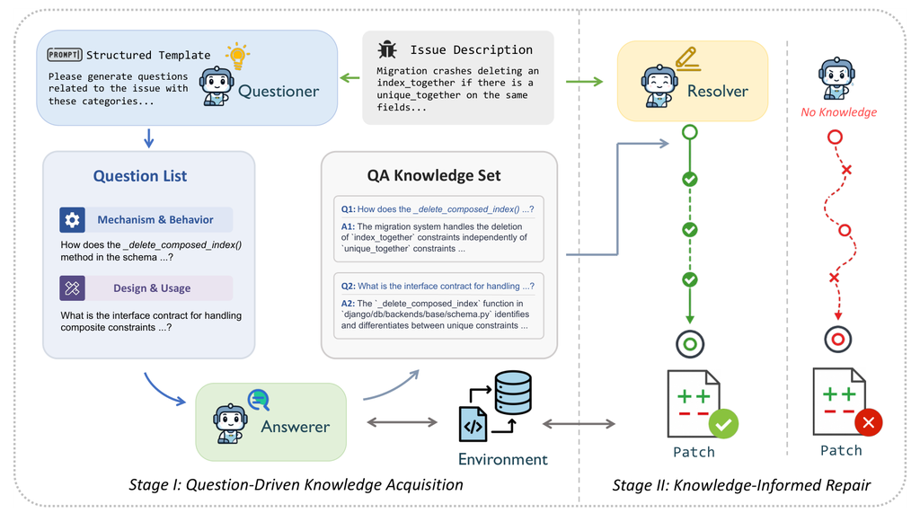

图 1｜ACQUIRE流程：出题者提出N个问题，N个并行的只读作答实例各自探索仓库，问答结果一次性注入修复者（原论文Figure 1）

## 三、效果：成功率上升，翻找行为发生改变

主结果见下表。两个底座模型上Pass@1分别提升3.8和4.4个百分点，成本增幅温和：GPT-5-mini单实例成本从0.024美元上升到0.054美元，DeepSeek-V3.2从0.055上升到0.073美元。

| 方法 | GPT-5-mini Pass@1 | DeepSeek-V3.2 Pass@1 | 成本与时间 |
| --- | --- | --- | --- |
| 基础智能体（无预取） | 58.4 | 66.4 | 最便宜最快 |
| LocAgent（可疑位置） | 57.8（降） | 68.8 | 小模型上不升反降 |
| CoSIL（结构摘要） | 55.2（降） | 68.7 | 小模型上降3.2 |
| LingmaAgent（摘要+规划） | 60.0 | 67.4 | 成本高一个量级 |
| SWE-Debate（多智能体辩论） | 59.8 | 68.2 | GPT-5-mini成本0.738美元 |
| ACQUIRE（出题-作答） | 62.2 | 70.8 | 相对辩论法成本约1/5 |

表 2｜主结果（原论文Table I，SWE-bench Verified 500实例，作者整理）

两组对比结果：第一组是给位置、给摘要的方法：LocAgent和CoSIL在DeepSeek-V3.2上有小幅提升，在GPT-5-mini上不升反降。论文的解释是，可疑位置和结构摘要属于浅层指针，能否用好取决于底座模型自己的推理能力。模型弱的时候指针反而使模型走错方向。问答式知识把“为什么”直接给了出来，对弱模型更友好。第二组是同样产出丰富上下文的LingmaAgent和SWE-Debate：它们有效但昂贵，SWE-Debate在DeepSeek-V3.2上单实例成本0.382美元、平均耗时2517秒，ACQUIRE把这两项分别压到0.073美元（降81%）和1042秒（缩短58%）。

行为层面的变化更能说明机制（图2）。注入问答后，智能体的平均交互轮数在全部500个实例上减少7.1%，在44个被成功修复的原失败实例上减少17.1%。把这44个实例的轨迹按定位、复现、修改、验证四个阶段拆开：总步数从3917降到3246，降幅集中在定位（减少23.8%）和修改（减少24.1%）这两个知识密集的阶段。复现和验证的步数占比反而上升。40.4%的步骤明确用到了问答知识，集中在定位（51.5%）和修改（50.6%）。翻找减少了，验证增多了，智能体的行为模式向“先理解再动手”的工程师靠拢。

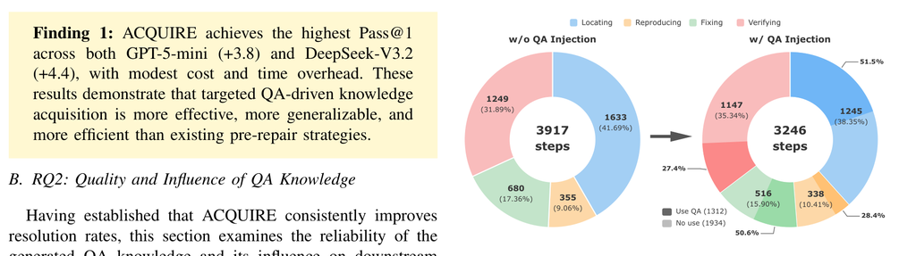

图 2｜44个救活实例的轨迹阶段构成：注入问答后，定位与修改的步骤明显缩短，复现与验证的占比上升（原论文Figure 2）

知识本身可靠吗？论文对232组问答做了人工审计（每组由两名有四年开发经验的研究生独立评审，分歧讨论解决）：230组（99.1%）有仓库证据支撑，其中42.2%完全准确。56.9%核心论断正确但行号、函数归属之类的细节有小偏差。只有2组（0.9%）包含与代码矛盾的无根据断言。论文把这个可靠率归因于任务分解：每个作答实例只回答一个窄问题，检索和推理的负担小，编造的空间也小。

## 四、两个反向验证和一个数量边界

这套设计里，真正关键的选择是哪几个？论文用消融实验逐一进行验证。

第一个消融把问答换成“写一段修复分析”：同样读issue、同样探索仓库，只是不提问，直接产出一段包含根因分析和修复建议的文字，注入给修复者。结果Pass@1下降4.8个百分点，降到66.0，比什么都不注入（66.4）还低。一段同时要找根因、推机制、给方案的分析，在复杂issue上往往写得面面俱到又处处肤浅，注入后反而把修复者带偏。把问题分解窄、每个单独作答，是这套方法成立的第一个关键因素。

第二个消融去掉四类模板，让出题者自由提问。Pass@1下降3.8个百分点，降到67.0。对生成问题的质量评估显示，差距最大的维度是覆盖度（自由提问5.97分，模板引导6.74分）——没有分类引导，问题容易集中在一个角度上。成对比较中，模板生成的问题在500次里赢294次、输111次。

数量上，问几个问题合适（图3）？一个问题时Pass@1就从66.4升到69.0（+2.6个百分点，多花0.005美元）；两个问题到峰值70.8；三个问题回落到69.0，成本继续涨到0.082美元。论文对回落的解释：第三个问题往往与前两个覆盖的知识重叠，而注入文本变长会稀释修复者的注意力。（参考本系列第二篇荐读论文，关于大模型有效上下文窗口的讨论）。

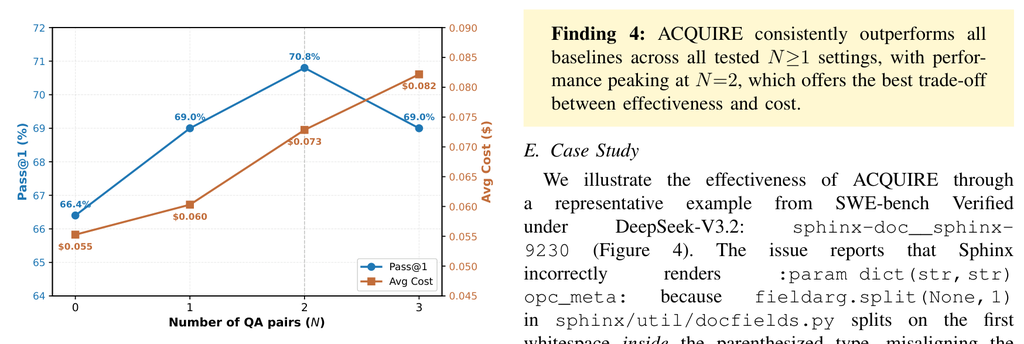

图 3｜问答数量N的影响：1问提升2.6个百分点，2问到峰值70.8，3问回落且成本继续上升（原论文Figure 3）

| 改动 | Pass@1 | 变化 | 说明 |
| --- | --- | --- | --- |
| ACQUIRE完整版 | 70.8 | — | 两个问题、模板引导 |
| 换成“写一段修复分析” | 66.0 | −4.8 | 低于不注入的66.4 |
| 去掉四类模板 | 67.0 | −3.8 | 覆盖度掉得最多 |
| 只问一个问题 | 69.0 | −1.8 | 成本仅+$0.005 |
| 问三个问题 | 69.0 | −1.8 | 知识重叠+注意力稀释 |

表 3｜消融与数量敏感性汇总（原论文Table II及Figure 3，DeepSeek-V3.2，作者整理）

## 五、22个回归样本的解剖：参考答案没错，模型的理解方向错了

实验中总共有44个失败转成功案例、22个成功转失败案例，净增22个。对其中成功转失败的22个案例进行进一步分析：逐条检查轨迹，判断是否注入的问答把修复者带偏了。结论是只有5个属于“问答误导”。其余17个，问答本身是中性或有用的。失败的原因在于修复者按照正确的线索做了过度推广，只改了一半、或者引入了不必要的改动。

更有信息量的是那5个误导案例的事实核查：涉及的10组问答里，9组事实完全有据。把修复带偏的多数是“相关但非根因”的机制描述。问答本身没有说错，只是修复者顺着这个框架反复搜索修改，越走越远。方向上的偏差，比事实错误更容易造成修复失败。论文由此给出判断：

"…the regression bottleneck lies in how the Resolver utilizes otherwise reliable QA, not in QA quality itself…"  
── 中译：回归的瓶颈在于修复者如何使用本来可靠的问答知识，而不在问答知识本身的质量。（原论文§V）

对使用者的启示：知识预取解决“给什么”，不解决“怎么用”。注入的知识质量再高，修复者如果不会批判性地核对与取舍，仍会被带偏。改进使用侧利用上下文的流程，让修复者对注入知识做校验，是论文建议的开放方向。

▍注记：这篇论文的边界

评测基于单一基准（SWE-bench Verified，500个Python实例）和单一主指标（Pass@1），成本与时间作辅助视角。四类问题模板是人工归纳的实用分类，论文自承可再细化（层级类别、按issue类型自适应）而不限于直接照搬。知识为一次性静态注入，“边修边按需提问”的动态获取是论文明确列出的开放方向，可能可以节省Token，但会带来更高的工程复杂性。22.4%恢复率来自受限的Oracle设定，应理解为此流程方法的效果下界。人工审计232对问答对、回归解剖22例失败案例，均为小样本。

▍先问后修，怎样在实际的工作流中应用

这篇论文的论证链条：Oracle实验证明相当一部分修复失败只缺知识（22.4%的失败案例可以通过补充信息纠正）。自动化的出题-作答-注入兑现了其中一部分（两个模型上分别+3.8和+4.4个百分点）；消融实验证实了两个关键设计（窄问题分解、分类模板）。回归解剖指出下一个瓶颈在于如何正确地使用补充信息。对照上一期：检索解决“材料能不能找到”，这篇论文为“动手之前该备哪些料”提供了参考建议。

1. 修bug类任务在动手前加上一个“出题-作答”的环节：让模型把issue拆成两三个具体问题（这个组件怎么运作／接口有什么约定／代码在哪），每个问题单独检索作答，答案要求带文件路径和函数名，如果找不到也明确反馈。

预取解决的是动手之前准备什么上下文资料。而上下文在进入窗口的那一刻怎么取舍，则是上下文管理的另一道工序了。

在AI Native的开发方式中，由大模型生成的代码在基础的语法准确性和局部处理逻辑上的bug率远远低于人类开发者。但限于注意力机制和有效上下文窗口的局限，跨模块依赖、契约遵循等方面问题造成的bug在所有bug中的占比较高。恰恰这一类问题，AI自动修复的成功率比较低。尤其在依赖关系复杂的大型系统开发中，直接使用AI来修改这一类bug很容易造成“越改越错”的情况。这篇论文给出了很有价值的工程方法。同时，在模型选型和整体开发流程设计上也有一定的启示：涉及跨模块复杂逻辑设计的部分，要选择能力强的模型。使用较强的模型把设计拆分到比较细的颗粒度，输出依赖关系和规约描述非常具体的详细设计文档，再使用相对便宜的Flash级别模型进行大工作量的代码生成，bug修复时再切回较强的模型，可能是较为合理的大小模型搭配策略。

论文：Know Before Fix（arXiv:2607.11111v1，2026-07，Haotian Lin et al.）。文中图表均引自原论文（Figure 1/2/3）；表1–3依据原论文§III-B1、Table I、Table II及Figure 3由作者整理，非原图截取；引文为原文直录并附中译；数字已逐项与论文PDF原文核对。